# LBB2

Luthfi

2023-10-18

# 1 Introduction

```r
library(knitr)
```

[figure not shown]

IMG_Source: https://freebiehive.com/spotify-logo-png/

This dataset contains a comprehensive list of the most famous songs of 2023 as listed on Spotify. The dataset offers a wealth of features beyond what is typically available in similar datasets. It provides insights into each song’s attributes, popularity, and presence on various music platforms.

Source: https://www.kaggle.com/datasets/nelgiriyewithana/top-spotify-songs-2023/data

## 1.1 Notes on Specific Variables

- `track_name`: Name of the song
- `artist(s)_name`: Name of the artist(s) of the song
- `artist_count`: Number of artists contributing to the song
- `released_year`: Year when the song was released
- `released_month`: Month when the song was released
- `released_day`: Day of the month when the song was released
- `in_spotify_playlists`: Number of Spotify playlists the song is included in
- `in_spotify_charts`: Presence and rank of the song on Spotify charts
- `streams`: Total number of streams on Spotify

## 1.2 Objectives

The objective of this Rmd are to find:

1. The most played song on Spotify
2. The most famous artist on Spotify
3. The most optimal way to release a song on Spotify to increase stream count

# 2 Data Preparation

The First step is inserting the csv file into R located in data_input and then installing the necessary plugins.

## 2.1 Importing Libraries

```r
# Libraries
library(dplyr) #install package dplyr to manipulate character data
```

```r
library(scales) #install package scales
library(ggplot2) #install package ggplot2 for data visualization
library(leaflet) #install package leaflet for map plotting
library(tidyr) #install package tidyr for seperating rows
library(stringi) #install package stringi for handling multibyte characters
```

## 2.2 Importing Dataset

```r
#Read data csv
spotify <- read.csv("data_input/spotify-2023.csv")
```

Inspecting the imported dataset using head()

```r
head(spotify)
```

|  | track_name | artist.s._name | artist_count | released_year | released_month | released_day | in_spotify_playlists | in_spotify_charts | streams | in_apple_playlists | in_apple_charts | in_deezer_playlists | in_deezer_charts | in_shazam_charts | bpm | key | mode | danceability_. | valence_. | energy_. | acousticness_. | instrumentalness_. | liveness_. | speechiness_. |
| --- | --- | --- | --- | --- | --- | --- | --- | --- | --- | --- | --- | --- | --- | --- | --- | --- | --- | --- | --- | --- | --- | --- | --- | --- |
| 1 | Seven (feat. Latto) (Explicit Ver.) | Latto, Jung Kook | 2 | 2023 | 7 | 14 | 553 | 147 | 141381703 | 43 | 263 | 45 | 10 | 826 | 125 | B | Major | 80 | 89 | 83 | 31 | 0 | 8 | 4 |
| 2 | LALA | Myke Towers | 1 | 2023 | 3 | 23 | 1474 | 48 | 133716286 | 48 | 126 | 58 | 14 | 382 | 92 | C# | Major | 71 | 61 | 74 | 7 | 0 | 10 | 4 |
| 3 | vampire | Olivia Rodrigo | 1 | 2023 | 6 | 30 | 1397 | 113 | 140003974 | 94 | 207 | 91 | 14 | 949 | 138 | F | Major | 51 | 32 | 53 | 17 | 0 | 31 | 6 |
| 4 | Cruel Summer | Taylor Swift | 1 | 2019 | 8 | 23 | 7858 | 100 | 800840817 | 116 | 207 | 125 | 12 | 548 | 170 | A | Major | 55 | 58 | 72 | 11 | 0 | 11 | 15 |
| 5 | WHERE SHE GOES | Bad Bunny | 1 | 2023 | 5 | 18 | 3133 | 50 | 303236322 | 84 | 133 | 87 | 15 | 425 | 144 | A | Minor | 65 | 23 | 80 | 14 | 63 | 11 | 6 |
| 6 | Sprinter | Dave, Central Cee | 2 | 2023 | 6 | 1 | 2186 | 91 | 183706234 | 67 | 213 | 88 | 17 | 946 | 141 | C# | Major | 92 | 66 | 58 | 19 | 0 | 8 | 24 |

# 3 Data Cleaning

## 3.1 Checking Datatypes

```r
str(spotify)
```

```
## 'data.frame':    953 obs. of  24 variables:
##  $ track_name          : chr  "Seven (feat. Latto) (Explicit Ver.)" "LALA" "vampire" "Cruel Summer" ...
##  $ artist.s._name      : chr  "Latto, Jung Kook" "Myke Towers" "Olivia Rodrigo" "Taylor Swift" ...
##  $ artist_count        : int  2 1 1 1 1 2 2 1 1 2 ...
##  $ released_year       : int  2023 2023 2023 2019 2023 2023 2023 2023 2023 2023 ...
##  $ released_month      : int  7 3 6 8 5 6 3 7 5 3 ...
##  $ released_day        : int  14 23 30 23 18 1 16 7 15 17 ...
##  $ in_spotify_playlists: int  553 1474 1397 7858 3133 2186 3090 714 1096 2953 ...
##  $ in_spotify_charts   : int  147 48 113 100 50 91 50 43 83 44 ...
##  $ streams             : chr  "141381703" "133716286" "140003974" "800840817" ...
##  $ in_apple_playlists  : int  43 48 94 116 84 67 34 25 60 49 ...
##  $ in_apple_charts     : int  263 126 207 207 133 213 222 89 210 110 ...
##  $ in_deezer_playlists : chr  "45" "58" "91" "125" ...
##  $ in_deezer_charts    : int  10 14 14 12 15 17 13 13 11 13 ...
##  $ in_shazam_charts    : chr  "826" "382" "949" "548" ...
##  $ bpm                 : int  125 92 138 170 144 141 148 100 130 170 ...
##  $ key                 : chr  "B" "C#" "F" "A" ...
##  $ mode                : chr  "Major" "Major" "Major" "Major" ...
##  $ danceability_.      : int  80 71 51 55 65 92 67 67 85 81 ...
##  $ valence_.           : int  89 61 32 58 23 66 83 26 22 56 ...
##  $ energy_.            : int  83 74 53 72 80 58 76 71 62 48 ...
##  $ acousticness_.      : int  31 7 17 11 14 19 48 37 12 21 ...
##  $ instrumentalness_.  : int  0 0 0 0 63 0 0 0 0 0 ...
##  $ liveness_.          : int  8 10 31 11 11 8 8 11 28 8 ...
##  $ speechiness_.       : int  4 4 6 15 6 24 3 4 9 33 ...
```

The songs listed in the data have a wide range of release dates, spanning from 1930 to 2023.

```r
summary(spotify$released_year)
```

```
##    Min. 1st Qu.  Median    Mean 3rd Qu.    Max.
##    1930    2020    2022    2018    2022    2023
```

From the table, it can be concluded that, on average, songs have only 1 artist, while only a few of the top Spotify songs are the result of collaborations with other artists.

```r
sort(table(spotify$artist_count), decreasing = T)
```

```
##
##   1   2   3   4   5   6   7   8
## 587 254  85  15   5   3   2   2
```

## 3.2 Subsetting

```r
spotify_sub <- select(spotify, 1:9)

spotify_sub
```

| track_name | artist.s._name | artist_count | released_year | released_month | released_day | in_spotify_playlists | in_spotify_charts | streams |
| --- | --- | --- | --- | --- | --- | --- | --- | --- |
| Seven (feat. Latto) (Explicit Ver.) | Latto, Jung Kook | 2 | 2023 | 7 | 14 | 553 | 147 | 141381703 |
| LALA | Myke Towers | 1 | 2023 | 3 | 23 | 1474 | 48 | 133716286 |
| vampire | Olivia Rodrigo | 1 | 2023 | 6 | 30 | 1397 | 113 | 140003974 |
| Cruel Summer | Taylor Swift | 1 | 2019 | 8 | 23 | 7858 | 100 | 800840817 |
| WHERE SHE GOES | Bad Bunny | 1 | 2023 | 5 | 18 | 3133 | 50 | 303236322 |
| Sprinter | Dave, Central Cee | 2 | 2023 | 6 | 1 | 2186 | 91 | 183706234 |
| Ella Baila Sola | Eslabon Armado, Peso Pluma | 2 | 2023 | 3 | 16 | 3090 | 50 | 725980112 |
| Columbia | Quevedo | 1 | 2023 | 7 | 7 | 714 | 43 | 58149378 |
| fukumean | Gunna | 1 | 2023 | 5 | 15 | 1096 | 83 | 95217315 |
| La Bebe - Remix | Peso Pluma, Yng Lvcas | 2 | 2023 | 3 | 17 | 2953 | 44 | 553634067 |

[output cut: 943 more lines]

## 3.3 New columns

```r
# Creating a new column for Month name
spotify_sub$month <- as.factor(month.abb[spotify_sub$released_month])

# Checking Head Data
head(spotify_sub)
```

|  | track_name | artist.s._name | artist_count | released_year | released_month | released_day | in_spotify_playlists | in_spotify_charts | streams | month |
| --- | --- | --- | --- | --- | --- | --- | --- | --- | --- | --- |
| 1 | Seven (feat. Latto) (Explicit Ver.) | Latto, Jung Kook | 2 | 2023 | 7 | 14 | 553 | 147 | 141381703 | Jul |
| 2 | LALA | Myke Towers | 1 | 2023 | 3 | 23 | 1474 | 48 | 133716286 | Mar |
| 3 | vampire | Olivia Rodrigo | 1 | 2023 | 6 | 30 | 1397 | 113 | 140003974 | Jun |
| 4 | Cruel Summer | Taylor Swift | 1 | 2019 | 8 | 23 | 7858 | 100 | 800840817 | Aug |
| 5 | WHERE SHE GOES | Bad Bunny | 1 | 2023 | 5 | 18 | 3133 | 50 | 303236322 | May |
| 6 | Sprinter | Dave, Central Cee | 2 | 2023 | 6 | 1 | 2186 | 91 | 183706234 | Jun |

## 3.4 Converting column type

```r
spotify_sub <- spotify_sub %>%
  mutate_at(vars(released_year, released_month, released_day), as.factor) %>%
  mutate(streams = as.integer(streams))
head(spotify_sub)
```

|  | track_name | artist.s._name | artist_count | released_year | released_month | released_day | in_spotify_playlists | in_spotify_charts | streams | month |
| --- | --- | --- | --- | --- | --- | --- | --- | --- | --- | --- |
| 1 | Seven (feat. Latto) (Explicit Ver.) | Latto, Jung Kook | 2 | 2023 | 7 | 14 | 553 | 147 | 141381703 | Jul |
| 2 | LALA | Myke Towers | 1 | 2023 | 3 | 23 | 1474 | 48 | 133716286 | Mar |
| 3 | vampire | Olivia Rodrigo | 1 | 2023 | 6 | 30 | 1397 | 113 | 140003974 | Jun |
| 4 | Cruel Summer | Taylor Swift | 1 | 2019 | 8 | 23 | 7858 | 100 | 800840817 | Aug |
| 5 | WHERE SHE GOES | Bad Bunny | 1 | 2023 | 5 | 18 | 3133 | 50 | 303236322 | May |
| 6 | Sprinter | Dave, Central Cee | 2 | 2023 | 6 | 1 | 2186 | 91 | 183706234 | Jun |

## 3.5 Missing Data

```r
spotify_sub[spotify_sub == ""] <- NA
str(spotify_sub)
```

```
## 'data.frame':    953 obs. of  10 variables:
##  $ track_name          : chr  "Seven (feat. Latto) (Explicit Ver.)" "LALA" "vampire" "Cruel Summer" ...
##  $ artist.s._name      : chr  "Latto, Jung Kook" "Myke Towers" "Olivia Rodrigo" "Taylor Swift" ...
##  $ artist_count        : int  2 1 1 1 1 2 2 1 1 2 ...
##  $ released_year       : Factor w/ 50 levels "1930","1942",..: 50 50 50 46 50 50 50 50 50 50 ...
##  $ released_month      : Factor w/ 12 levels "1","2","3","4",..: 7 3 6 8 5 6 3 7 5 3 ...
##  $ released_day        : Factor w/ 31 levels "1","2","3","4",..: 14 23 30 23 18 1 16 7 15 17 ...
##  $ in_spotify_playlists: int  553 1474 1397 7858 3133 2186 3090 714 1096 2953 ...
##  $ in_spotify_charts   : int  147 48 113 100 50 91 50 43 83 44 ...
##  $ streams             : int  141381703 133716286 140003974 800840817 303236322 183706234 725980112 58149378 95217315 553634067 ...
##  $ month               : Factor w/ 12 levels "Apr","Aug","Dec",..: 6 8 7 2 9 7 8 6 9 8 ...
```

```r
colSums(is.na(x = spotify_sub))
```

```
##           track_name       artist.s._name         artist_count
##                    0                    0                    0
##        released_year       released_month         released_day
##                    0                    0                    0
## in_spotify_playlists    in_spotify_charts              streams
##                    0                    0                   26
##                month
##                    0
```

```r
spotify_sub <- na.omit(spotify_sub)
```

## 3.6 Duplicates

```r
spotify_sub <- spotify_sub[!duplicated(spotify_sub$track_name, fromLast = TRUE), ]
```

## 3.7 Separating Rows

Separating rows of songs who has two or more artists.

```r
spotify_sep <- separate_rows(spotify_sub, artist.s._name, sep = ",")
head(spotify_sep)
```

| track_name | artist.s._name | artist_count | released_year | released_month | released_day | in_spotify_playlists | in_spotify_charts | streams | month |
| --- | --- | --- | --- | --- | --- | --- | --- | --- | --- |
| Seven (feat. Latto) (Explicit Ver.) | Latto | 2 | 2023 | 7 | 14 | 553 | 147 | 141381703 | Jul |
| Seven (feat. Latto) (Explicit Ver.) | Jung Kook | 2 | 2023 | 7 | 14 | 553 | 147 | 141381703 | Jul |
| LALA | Myke Towers | 1 | 2023 | 3 | 23 | 1474 | 48 | 133716286 | Mar |
| vampire | Olivia Rodrigo | 1 | 2023 | 6 | 30 | 1397 | 113 | 140003974 | Jun |
| Cruel Summer | Taylor Swift | 1 | 2019 | 8 | 23 | 7858 | 100 | 800840817 | Aug |
| WHERE SHE GOES | Bad Bunny | 1 | 2023 | 5 | 18 | 3133 | 50 | 303236322 | May |

# 4 Data Processing

```r
# Load data set
spotify_sub
```

|  | track_name | artist.s._name | artist_count | released_year | released_month | released_day | in_spotify_playlists | in_spotify_charts | streams | month |
| --- | --- | --- | --- | --- | --- | --- | --- | --- | --- | --- |
| 1 | Seven (feat. Latto) (Explicit Ver.) | Latto, Jung Kook | 2 | 2023 | 7 | 14 | 553 | 147 | 141381703 | Jul |
| 2 | LALA | Myke Towers | 1 | 2023 | 3 | 23 | 1474 | 48 | 133716286 | Mar |
| 3 | vampire | Olivia Rodrigo | 1 | 2023 | 6 | 30 | 1397 | 113 | 140003974 | Jun |
| 4 | Cruel Summer | Taylor Swift | 1 | 2019 | 8 | 23 | 7858 | 100 | 800840817 | Aug |
| 5 | WHERE SHE GOES | Bad Bunny | 1 | 2023 | 5 | 18 | 3133 | 50 | 303236322 | May |
| 6 | Sprinter | Dave, Central Cee | 2 | 2023 | 6 | 1 | 2186 | 91 | 183706234 | Jun |
| 7 | Ella Baila Sola | Eslabon Armado, Peso Pluma | 2 | 2023 | 3 | 16 | 3090 | 50 | 725980112 | Mar |
| 8 | Columbia | Quevedo | 1 | 2023 | 7 | 7 | 714 | 43 | 58149378 | Jul |
| 9 | fukumean | Gunna | 1 | 2023 | 5 | 15 | 1096 | 83 | 95217315 | May |
| 10 | La Bebe - Remix | Peso Pluma, Yng Lvcas | 2 | 2023 | 3 | 17 | 2953 | 44 | 553634067 | Mar |

[output cut: 907 more lines]

## 4.1 Most played Song in Spotify

```r
# Groupping new data set by track_name
top_spotify <- spotify_sub %>%
  group_by(track_name) %>%
  arrange(-streams) %>%
  head(20,)

#Necessary columns
top_spotify[c("track_name", "streams")]
```

| track_name | streams |
| --- | --- |
| Take Me To Church | 2135158446 |
| Circles | 2132335812 |
| Love Yourself | 2123309722 |
| All of Me | 2086124197 |
| Counting Stars | 2011464183 |
| Riptide | 2009094673 |
| Wake Me Up - Radio Edit | 1970673297 |
| Can't Hold Us (feat. Ray Dalton) | 1953533826 |
| The Hills | 1947371785 |
| HUMBLE. | 1929770265 |

[output cut: 10 more lines]

From the plot, it can be read that the most popular songs on Spotify in 2023 are “Take Me To Church,” “Circles,” and “Love Yourself.”

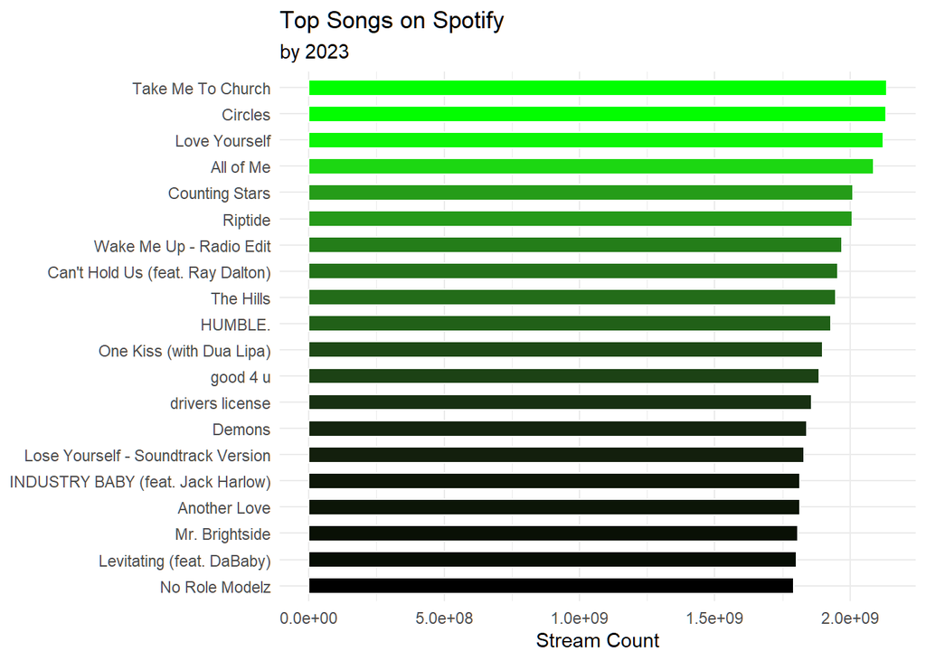

```r
#Plotting Top Songs on Spotify
ggplot(data = top_spotify, aes(x = streams,
                              y = reorder(track_name, streams), fill = streams) # Add fill aesthetic
                ) +
  geom_col(width = 0.6, col = "white") +
  scale_fill_gradient(low = "black", high = "green") +
    labs(title="Top Songs on Spotify",
       subtitle="by 2023",
       x = "Stream Count",
       y = NULL) +
  theme_minimal() +
  theme(legend.position = "none")
```

## Top Artist on Spotify

```r
artist_spotify <- spotify_sep %>%
  group_by(artist.s._name) %>%
  summarise(stream = sum(streams)) %>%
  ungroup() %>%
  arrange(-stream)%>%
  head(20,)


artist_spotify
```

| artist.s._name | stream |
| --- | --- |
| Bad Bunny | 15044237688 |
| Taylor Swift | 14423238266 |
| The Weeknd | 13468474945 |
| Eminem | 10193727260 |
| Bad Bunny | 8449742828 |
| Olivia Rodrigo | 7442148916 |
| Bruno Mars | 7346351599 |
| Harry Styles | 6772877034 |
| SZA | 6493011189 |
| Arctic Monkeys | 5569806731 |

[output cut: 10 more lines]

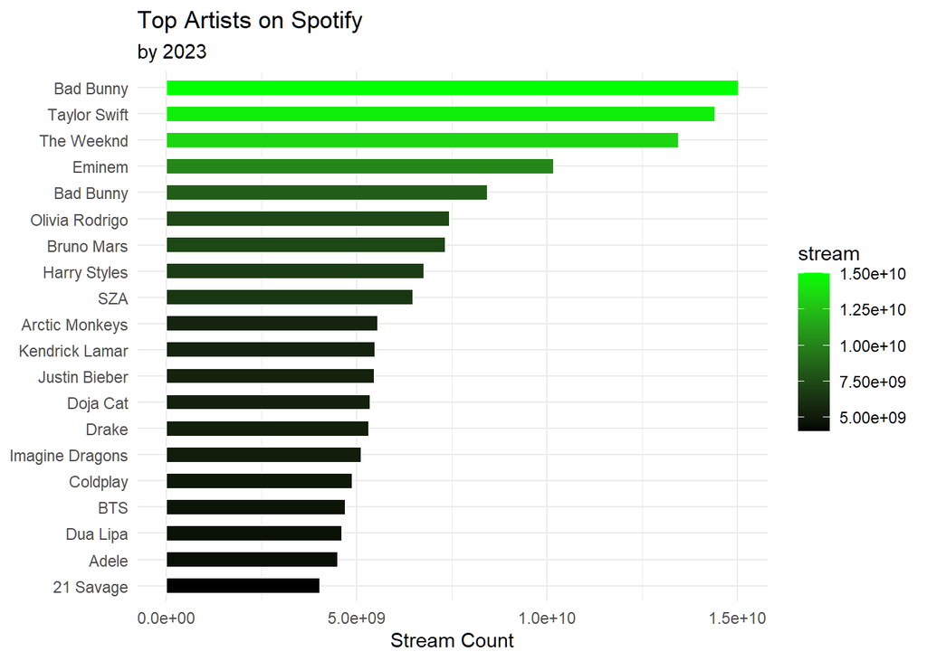

```r
#Plotting Top Artists on Spotify
ggplot(data = artist_spotify, aes(x = stream,
                              y = reorder(artist.s._name, stream), fill = stream) # Add fill aesthetic
                ) +
  geom_col(width = 0.6, col = "white") +
  scale_fill_gradient(low = "black", high = "green") +
    labs(title="Top Artists on Spotify",
       subtitle="by 2023",
       x = "Stream Count",
       y = NULL) +
  theme_minimal()
```

```r
spotify_sub
```

|  | track_name | artist.s._name | artist_count | released_year | released_month | released_day | in_spotify_playlists | in_spotify_charts | streams | month |
| --- | --- | --- | --- | --- | --- | --- | --- | --- | --- | --- |
| 1 | Seven (feat. Latto) (Explicit Ver.) | Latto, Jung Kook | 2 | 2023 | 7 | 14 | 553 | 147 | 141381703 | Jul |
| 2 | LALA | Myke Towers | 1 | 2023 | 3 | 23 | 1474 | 48 | 133716286 | Mar |
| 3 | vampire | Olivia Rodrigo | 1 | 2023 | 6 | 30 | 1397 | 113 | 140003974 | Jun |
| 4 | Cruel Summer | Taylor Swift | 1 | 2019 | 8 | 23 | 7858 | 100 | 800840817 | Aug |
| 5 | WHERE SHE GOES | Bad Bunny | 1 | 2023 | 5 | 18 | 3133 | 50 | 303236322 | May |
| 6 | Sprinter | Dave, Central Cee | 2 | 2023 | 6 | 1 | 2186 | 91 | 183706234 | Jun |
| 7 | Ella Baila Sola | Eslabon Armado, Peso Pluma | 2 | 2023 | 3 | 16 | 3090 | 50 | 725980112 | Mar |
| 8 | Columbia | Quevedo | 1 | 2023 | 7 | 7 | 714 | 43 | 58149378 | Jul |
| 9 | fukumean | Gunna | 1 | 2023 | 5 | 15 | 1096 | 83 | 95217315 | May |
| 10 | La Bebe - Remix | Peso Pluma, Yng Lvcas | 2 | 2023 | 3 | 17 | 2953 | 44 | 553634067 | Mar |

[output cut: 907 more lines]

## 4.2 Most Optimal Way to Release Songs on Spotify

```r
#Creating a new column to count the number of song released per ROW
spotify_sub <- spotify_sub %>%
  mutate(nsong = "1") %>%
  mutate(nsong = as.integer(nsong))
```

```r
#Creating a new dataset
month_spotify <- spotify_sub %>%
  group_by(month) %>%
  summarise(songs = sum(nsong)) %>%
  ungroup()

#Creating a new order for dataset
m_order <- c(
  "Jan", "Feb", "Mar", "Apr", "May", "Jun",
  "Jul", "Aug", "Sep", "Oct", "Nov", "Dec"
)

month_spotify <- month_spotify[match(m_order, month_spotify$month),]

month_spotify
```

| month | songs |
| --- | --- |
| Jan | 128 |
| Feb | 60 |
| Mar | 83 |
| Apr | 64 |
| May | 125 |
| Jun | 82 |
| Jul | 60 |
| Aug | 43 |
| Sep | 53 |
| Oct | 69 |

[output cut: 2 more lines]

From the plot, it can be discerned that many songs released in January become popular, followed by May with a similar number of songs.

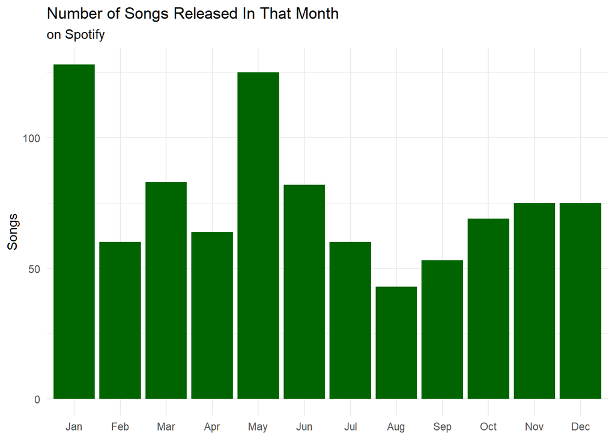

```r
#Plotting
ggplot(data = month_spotify, aes(x = month, y = songs, fill = songs)) +
  geom_bar(stat = "identity", fill = "darkgreen") +
  labs(
    title = "Number of Songs Released In That Month",
    subtitle="on Spotify",
    x = NULL,
    y = "Songs"
  ) +
  theme_minimal()+
  scale_x_discrete(limits = m_order)
```

```r
#Creating a new dataset
month_spotify_streams <- spotify_sub %>%
  group_by(month) %>%
  summarise(stream = sum(streams)) %>%
  ungroup()



month_spotify_streams <- month_spotify_streams[match(m_order, month_spotify_streams$month),]

month_spotify_streams
```

| month | stream |
| --- | --- |
| Jan | 84444781305 |
| Feb | 19338282906 |
| Mar | 36425603343 |
| Apr | 23572141572 |
| May | 45466851555 |
| Jun | 25695689988 |
| Jul | 26505703220 |
| Aug | 26054621213 |
| Sep | 33994746056 |
| Oct | 35378517854 |

[output cut: 2 more lines]

From the plot, it can be observed that January has the highest number of song streams, followed by May and March. However, there is a significant difference in the number of streams between January and May.

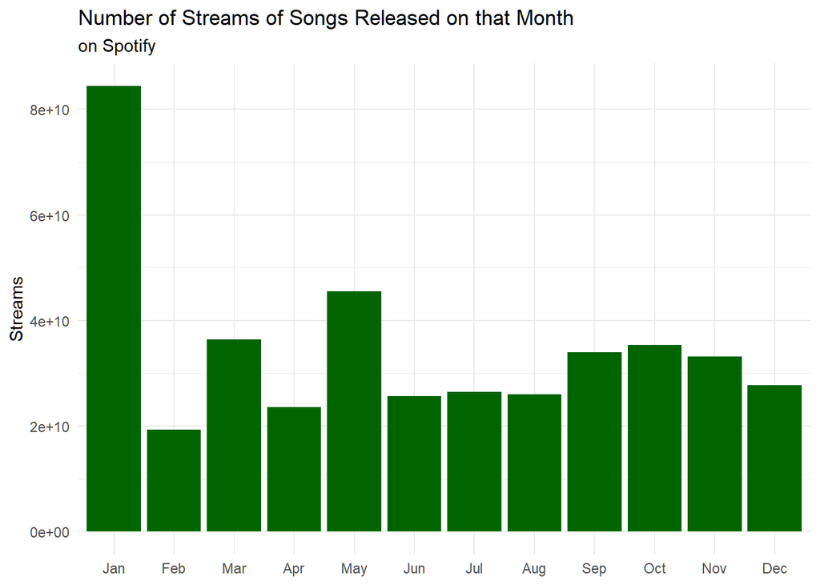

```r
#Plotting
ggplot(data = month_spotify_streams, aes(x = month, y = stream, fill = stream)) +
  geom_bar(stat = "identity", fill = "darkgreen") +
  labs(
    title = "Number of Streams of Songs Released on that Month",
    subtitle="on Spotify",
    x = NULL,
    y = "Streams"
  ) +
  theme_minimal()+
  scale_x_discrete(limits = m_order)
```

```r
#Combining two datasets
month_spotify_comb <- full_join (month_spotify, month_spotify_streams, by = "month") %>%
  group_by (month) %>%
  mutate(avg_stream = stream / songs) #new column to count average streams per song released on the month

month_spotify_comb
```

| month | songs | stream | avg_stream |
| --- | --- | --- | --- |
| Jan | 128 | 84444781305 | 659724854 |
| Feb | 60 | 19338282906 | 322304715 |
| Mar | 83 | 36425603343 | 438862691 |
| Apr | 64 | 23572141572 | 368314712 |
| May | 125 | 45466851555 | 363734812 |
| Jun | 82 | 25695689988 | 313362073 |
| Jul | 60 | 26505703220 | 441761720 |
| Aug | 43 | 26054621213 | 605921424 |
| Sep | 53 | 33994746056 | 641410303 |
| Oct | 69 | 35378517854 | 512732143 |

[output cut: 2 more lines]

From the plot, it can be concluded that the highest average streams are typically in January, followed by September and August. Despite many songs being released in May, the average stream count in that month is relatively low compared to other months.

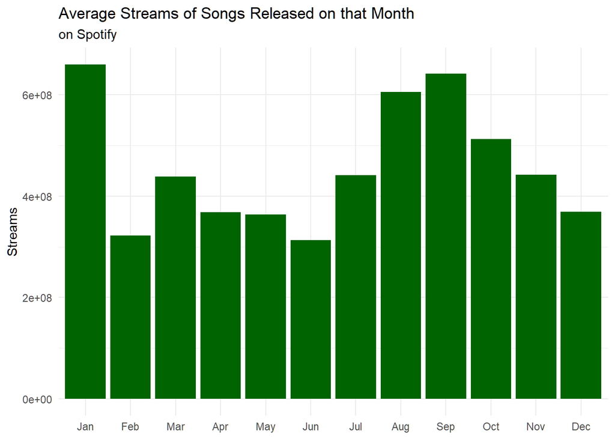

```r
ggplot(data = month_spotify_comb, aes(x = month, y = avg_stream, fill = avg_stream)) +
  geom_bar(stat = "identity", fill = "darkgreen") +
  labs(
    title = "Average Streams of Songs Released on that Month",
    subtitle="on Spotify",
    x = NULL,
    y = "Streams"
  ) +
  theme_minimal()+
  scale_x_discrete(limits = m_order)
```

# 5 SUMMARY

In 2023, the **songs ruling Spotify** are **Take Me To Church**, **Circles**, and **Love Yourself**, while the **top artists** include **Bad Bunny**, **Taylor Swift**, and **The Weeknd**.January stands out as a big month for music, with a flood of new releases and the highest average stream counts. It’s a time when both artists and listeners eagerly embrace the year with new music.

📌 The most popular songs on Spotify in 2023 are: “Take Me To Church,” “Circles,” and “Love Yourself.”

📌 The most popular artists on Spotify in 2023 are: Bad Bunny, Taylor Swift, and The Weeknd.